# Data Analysis 1: Descriptive Statistics and Data Transformations

SKPM20: Quantitative Methods 2026

nils.holmberg@iko.lu.se

## Presentation

- Nils Holmberg
- Digital marketing
- Computational  
  content analysis
- Cognitive  
  communication effects

[video not shown]

## Course literature

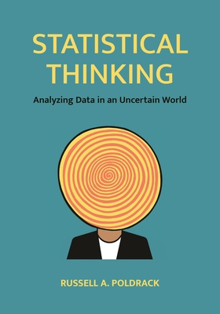

Poldrack (2023)

[figure not shown]

Field (2022)

[figure not shown]

Van de Ven (2007)

## Open science methods

- **Replicability**: Python enables reproducible research with shareable scripts.
- **Transparency**: Open-source code makes analyses fully visible.
- **Collaboration**: Supports teamwork via GitHub and Jupyter Notebooks.
- **Open Source**: Free and community-driven for open science. 🚀

## AI use in academic work

- OK: brainstorm ideas, do research
- OK: generate project materials
- OK: data analysis, statistics tools
- Not OK: copy-paste text to your exam
- Not OK: generate fake empirical data
- Not OK: upload content you dont own
- Not OK: upload data with personal info
- https://gemini.google.com/

## Lecture overview

- `Data collection`
- Survey, queationnaire
- Content analysis
- Process tracing
- `Data analysis`
- Course module
- Written assignment
- `Descriptive stats`
- Univariate analysis
- Visualizing data
- `Data transformations`
- Handle missingness
- Select, filter data
- Recode variables

Data Collection

## Survey, questionnaire

- attitude measurement
- knowledge, behaviors
- self-reported data
- population, sample size
- [online experiments](https://github.com/nils-holmberg/scom-expm)

```
graph LR
    direction LR

    subgraph Analysis [Factors expected to influence co-workers <br/>perceived access to information]
        direction LR

        %% Independent Variables
        iv1(co-worker age)
        iv2(co-worker role)
        iv3(organization type)

        %% Dependent Variable
        dv1[[<b>co-worker <br/>perceived access <br/>to information</b>]]

        %% Connections
        iv1 --> dv1
        iv2 --> dv1
        iv3 --> dv1
    end

    %% Node Styling
    style Analysis fill:#f9f9f9,stroke:#ccc,stroke-dasharray: 5 5
    style iv1 fill:#ffffff,stroke:#333,color:#000
    style iv2 fill:#ffffff,stroke:#333,color:#000
    style iv3 fill:#ffffff,stroke:#333,color:#000
    style dv1 fill:#517699,stroke:#2b4156,color:#fff

    %% Darker Arrow Styling (Indices start at 0)
    linkStyle 0,1,2 stroke:#000,stroke-width:2px;
```

## Content analysis

- quantitative content analysis
- computational content analysis
- natural language processing
  - named entity recognition (ner)
  - sentiment analysis
- computer vision
  - emotion recognition
  - object recognition

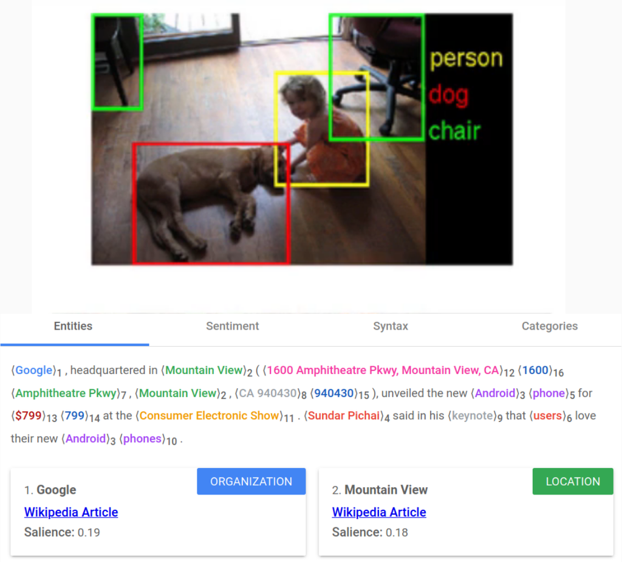

## Process tracing

- interaction over time
- eye-tracking
- psychophysiology
- web analytics
- computer interaction

[video not shown]

Data Analysis

## Descriptive Statistics

- Summarize central tendencies of attitudes or behaviors
- Report spread to capture social variation and inequality
- Use frequency tables for categorical responses
- Inspect distributions before modeling
- Pair numbers with visuals for transparency

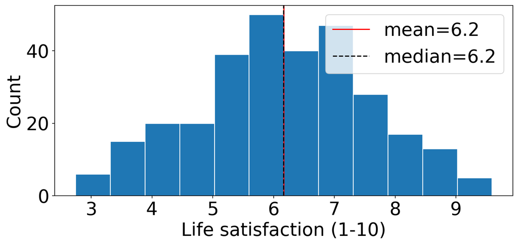

## Data Transformation

- Recode survey items into usable categories
- Handle missing values to avoid bias
- Create indicators for policy exposure or group status
- Standardize scales to compare across instruments
- Document transformations for reproducibility

```python
import pandas as pd

survey = pd.DataFrame({
    "education": ["HS", "BA", "BA", "MA", None, "HS"],
    "income": [25, 55, 42, 80, 36, None],
})
#print(survey)

# recode education to ordered levels
levels = {"HS": 1, "BA": 2, "MA": 3}
survey["edu_level"] = survey["education"].map(levels)
print(survey)

# fill missing income with median (simple example)
#survey["income_filled"] = survey["income"].fillna(survey["income"].median())
```

```
  education  income  edu_level
0        HS    25.0        1.0
1        BA    55.0        2.0
2        BA    42.0        2.0
3        MA    80.0        3.0
4      None    36.0        NaN
5        HS     NaN        1.0
```

## Bivariate Analysis

- Explore relationships like income and political trust
- Use scatterplots for two continuous measures
- Use boxplots for continuous vs categorical
- Check correlation but also inspect nonlinearity
- Identify outliers that may reflect real subgroups

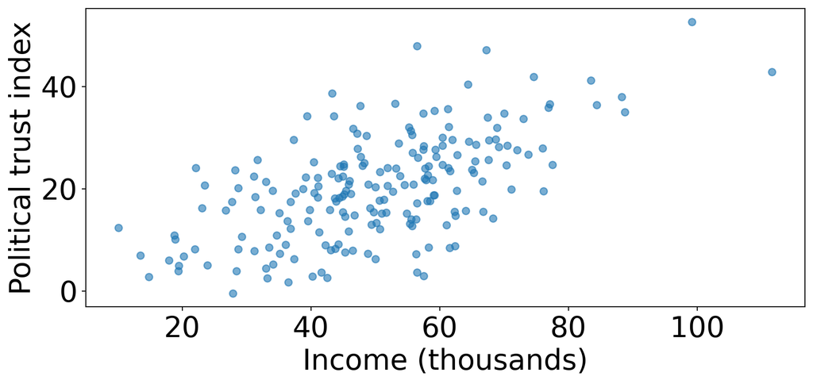

## Hypothesis Testing

- Compare means across groups (e.g., gender gaps)
- Use t-tests or nonparametric alternatives
- Emphasize effect sizes, not only p-values
- Check assumptions and sample sizes
- Interpret results in social context

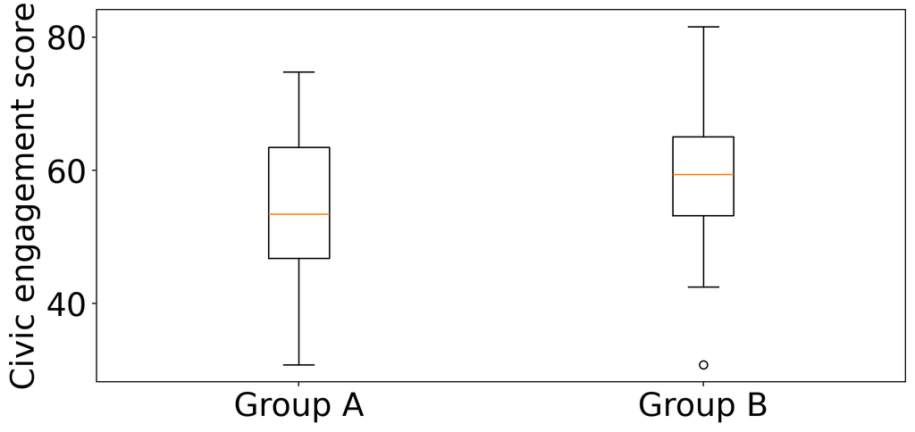

## Multivariate Analysis

- Estimate independent effects with controls
- Reduce confounding in observational studies
- Compare nested models across theory blocks
- Use diagnostics to assess fit and influence
- Translate coefficients into substantive effects

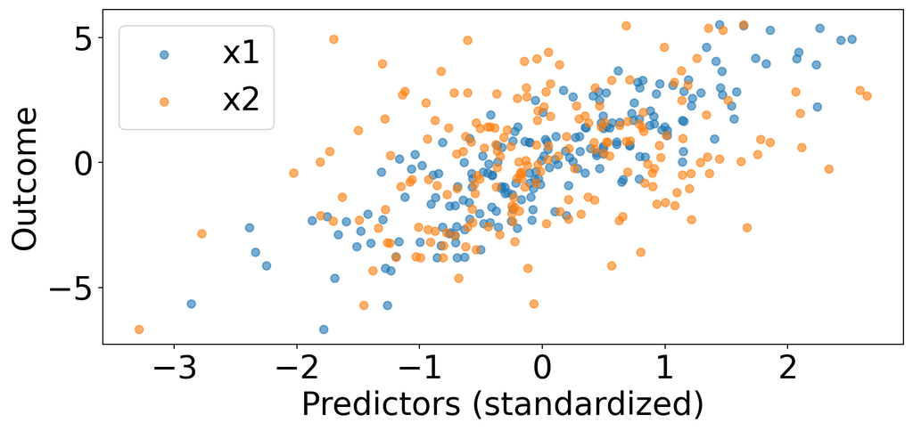

## Factor Analysis

- Identify hidden dimensions (e.g., ideology)
- Reduce many items into interpretable factors
- Assess loadings to validate constructs
- Compare factors across groups or time
- Use for scale development and validation

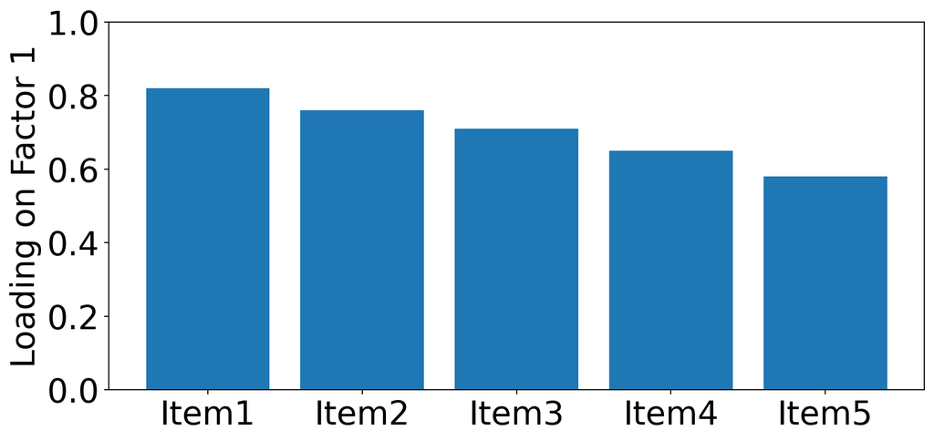

## Written assignment

- Download sample [dataset](https://github.com/cca-cce/osm-comm/raw/refs/heads/main/csv/cod-260120.xlsx) and analyze model
- Perform descriptive statistics
- Perform relevant data transformations
- Perform bivariate analyses and formulate hypotheses
- Perform multiple regression analysis

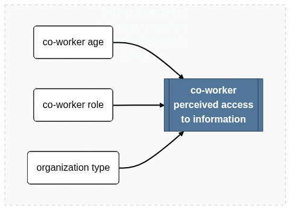

Descriptive Statistics

## Data Types and Measurement Scales

- Classify variables as categorical or quantitative
- Distinguish binary, integer, and real values
- Map scales: nominal, ordinal, interval, ratio
- Match statistics to scale (mode, median, mean)
- Avoid meaningless operations on labels

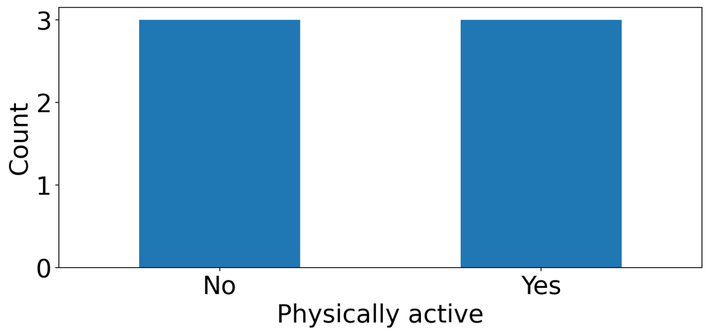

## Frequency Distributions

- Count how often each value occurs
- Use tables for categorical variables
- Summaries reduce raw data complexity
- Useful first check for data quality
- Foundation for plots and further stats

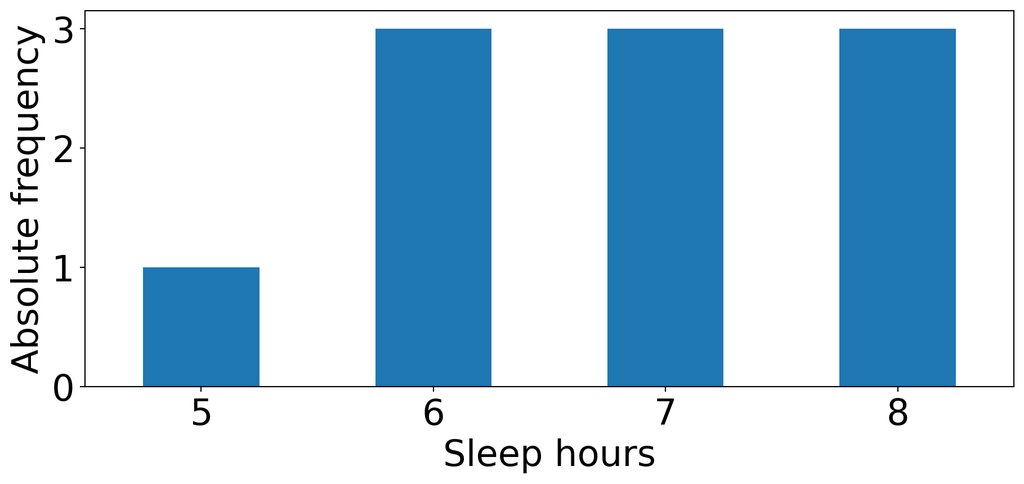

## Relative and Cumulative Frequency

- Convert counts to proportions or percents
- Compare groups with different sample sizes
- Cumulative frequency shows running totals
- Identify medians and percentiles visually
- Highlights distribution shifts and tails

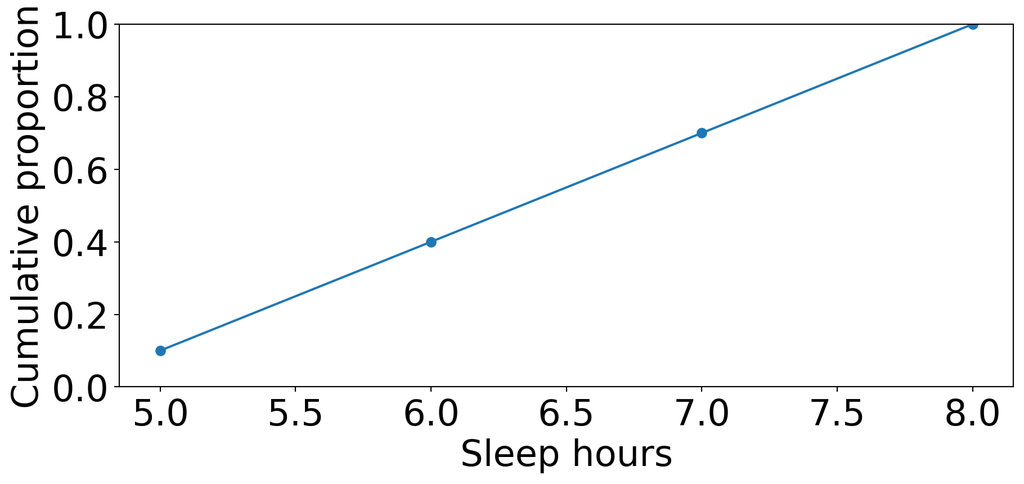

## Histograms and Binning

- Continuous data need bins to summarize
- Bin width controls smoothness vs detail
- Histograms reveal shape and spread
- Choose bins carefully to avoid artifacts
- Use bins to compare subgroups consistently

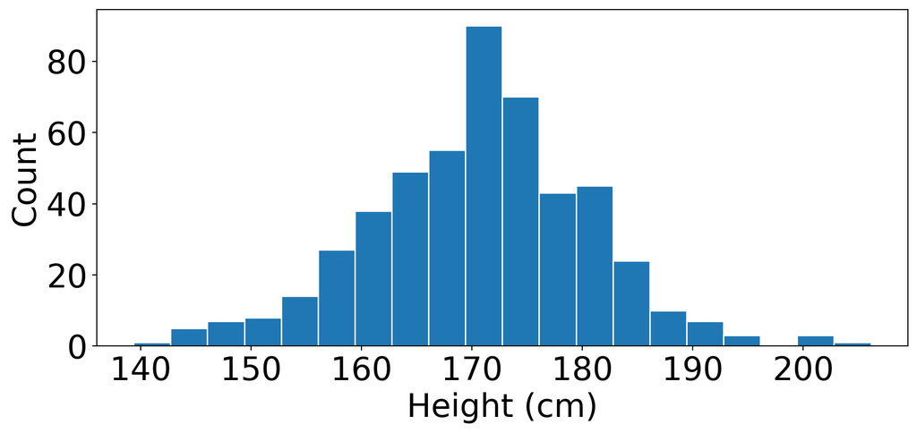

## Center and Spread

- Mean summarizes typical value
- Median resists skew and outliers
- Standard deviation measures spread
- Use multiple summaries together
- Pair summaries with distribution plots

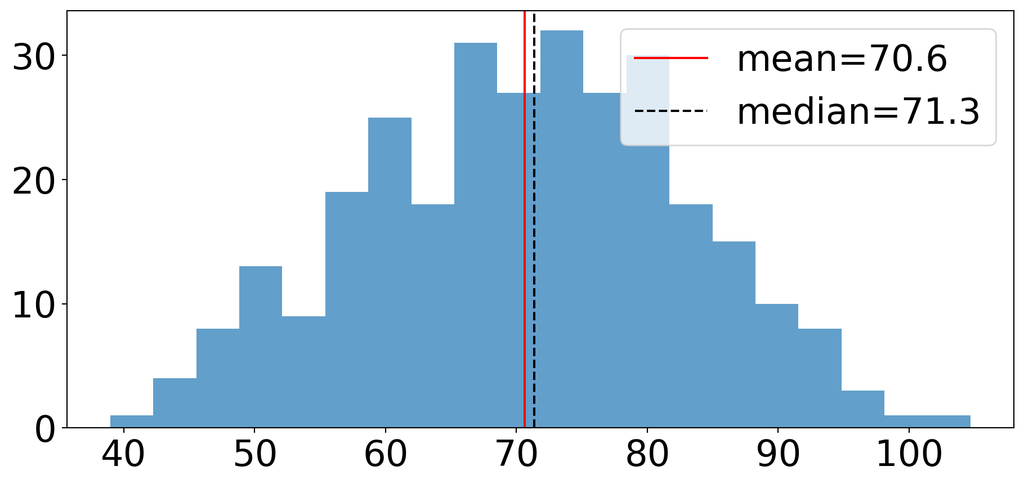

## Distribution Shape

- Normal distributions are symmetric
- Skewness shows longer right or left tails
- Long tails appear in network data
- Shape influences which stats to trust
- Visuals reveal features summaries hide

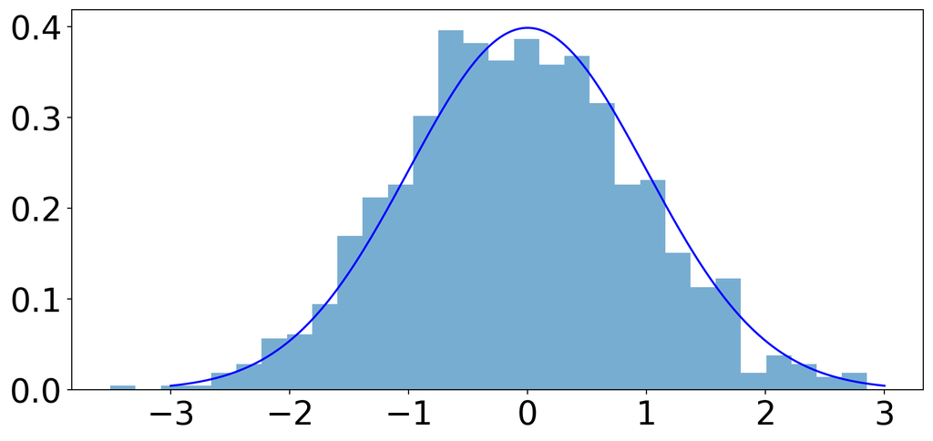

Data Transformations

## Filtering and Subsetting

- Focus analyses on relevant cases
- Remove impossible or invalid values
- Filter by age or group for clarity
- Keep transformations reproducible
- Always report filter criteria

```python
import pandas as pd

nhanes = pd.DataFrame({
    "Age": [12, 25, 34, 17, 52, 45],
    "Height": [145, 172, 168, 160, 175, 180],
})

adults = nhanes[nhanes["Age"] > 17]
print(adults)
```

```
   Age  Height
1   25     172
2   34     168
4   52     175
5   45     180
```

## Handling Missing Values

- Missingness can bias summaries
- Drop or impute based on context
- Keep a separate missing indicator
- Report how many values were missing
- Prefer simple, transparent choices

```python
import pandas as pd

sleep = pd.Series([6, None, 7, 8, None, 5])
clean = sleep.dropna()
filled = sleep.fillna(sleep.median())
print(clean)
print(filled)
```

```
0    6.0
2    7.0
3    8.0
5    5.0
dtype: float64
0    6.0
1    6.5
2    7.0
3    8.0
4    6.5
5    5.0
dtype: float64
```

## Creating Derived Variables

- Build indicators like is_child
- Convert units (inches to cm)
- Recode categories for clarity
- Combine variables into indices
- Preserve raw columns when possible

```python
import pandas as pd

nhanes = pd.DataFrame({"Age": [12, 25, 34, 17, 52, 45]})
nhanes["is_child"] = nhanes["Age"] < 18
print(nhanes)
```

```
   Age  is_child
0   12      True
1   25     False
2   34     False
3   17      True
4   52     False
5   45     False
```

## Grouping and Aggregation

- Summaries are built from group-by
- Compute means, medians, counts
- Compare subgroups side by side
- Support plots like bar charts
- Check sample sizes for each group

```python
import pandas as pd

nhanes = pd.DataFrame({
    "Sex": ["F", "F", "M", "M", "F"],
    "Height": [162, 168, 175, 180, 158],
})
print(nhanes)
summary = nhanes.groupby("Sex")["Height"].mean()
print(summary)
```

```
  Sex  Height
0   F     162
1   F     168
2   M     175
3   M     180
4   F     158
Sex
F    162.666667
M    177.500000
Name: Height, dtype: float64
```

## Reshaping for Visualization

- Wide data is hard to plot
- Long format simplifies faceting
- Use melt to gather columns
- Keep variable names explicit
- Reshape before plotting trends

```python
import pandas as pd

wide = pd.DataFrame({
    "year": [2010, 2011],
    "Unadjusted": [2.8, 3.5],
    "Adjusted": [3.1, 3.2],
})
long = wide.melt(id_vars=["year"], var_name="Type", value_name="Price")
print(long)
```

```
   year        Type  Price
0  2010  Unadjusted    2.8
1  2011  Unadjusted    3.5
2  2010    Adjusted    3.1
3  2011    Adjusted    3.2
```

## Adjusting for Other Factors

- Raw values can mislead across time
- Adjust for inflation or population
- Use per-capita rates for fairness
- Keep both raw and adjusted series
- Interpret changes in context

```python
import pandas as pd

prices = pd.DataFrame({
    "year": [1950, 1960, 1970],
    "Unadjusted": [0.27, 0.31, 0.36],
    "CPI": [24.1, 29.6, 38.8],
})
base_cpi = prices.loc[prices["year"] == 1950, "CPI"].iloc[0]
prices["Adjusted"] = prices["Unadjusted"] / (prices["CPI"] / base_cpi)
print(prices)
```

```
   year  Unadjusted   CPI  Adjusted
0  1950        0.27  24.1  0.270000
1  1960        0.31  29.6  0.252399
2  1970        0.36  38.8  0.223608
```

## Next steps

**Lecture lab 1, feb 2**

- Lecture notes: https://cca-cce.github.io/osm-comm/web/edu/skpm20-lecture-lab1.html
- Lab notebook: https://colab.research.google.com/github/cca-cce/osm-comm/blob/main/jnb/skpm20_labs.ipynb

**References**

Field, Andy. 2022. “An Adventure in Statistics: The Reality Enigma.”

Poldrack, R. 2023. *Statistical Thinking: Analyzing Data in an Uncertain World*. Princeton University Press. https://statsthinking21.github.io/statsthinking21-core-site/.

Van de Ven, Andrew H. 2007. *Engaged Scholarship: A Guide for Organizational and Social Research*. Oxford University Press.